# Dynamic Optimization with Open-Source Tools

Session 1: Julia, optimization, and a static reservoir

Diego S. Cardoso

University of Illinois Urbana-Champaign

## Workshop roadmap

1. **Julia, optimization, and a static reservoir**
2. The Bellman equation on a discrete state
3. Continuous state: finite and infinite horizon

## Before we start

- Everything runs in the GitHub Codespace you opened before today
- If `setup/smoke_test.jl` did not pass, say so in the chat now
- Files for today, in the `exercises/` folder
  - `s1_warmup.jl`: run along with the first part, nothing to fill in
  - `s1_inclass.jl`: four blanks that we fill together
  - `s1_homework.jl`: take it further, solutions are in `solutions/`

## Agenda

1. Julia by translation, for people who already program
2. One reservoir, one season: a static optimization problem
3. Break
4. What the static model says and what it misses

## Sources

- Miranda and Fackler, *Applied Computational Economics and Finance*, Chapter 7, for the calibration
- JuMP documentation: [Getting started with Julia](https://jump.dev/JuMP.jl/stable/tutorials/getting_started/getting_started_with_julia/#Getting-started-with-Julia) and [Getting started with JuMP](https://jump.dev/JuMP.jl/stable/tutorials/getting_started/getting_started_with_JuMP/#Getting-started-with-JuMP)
- [Julia documentation](https://docs.julialang.org/)

# 1. Julia by translation

## What this part is not

This part will **NOT** teach you how to program

Hopefully, you already program in R, Python, Matlab, or Stata. Julia will feel familiar for a day and then surprise you in a couple of places

We will focus on those places today

## Running code

Open `exercises/s1_warmup.jl` in the Codespace

- Put the cursor on a line, press **Shift+Enter**: the line runs in the Julia REPL
- Select a block, Shift+Enter: the block runs
- The whole file: `include("exercises/s1_warmup.jl")`

The first call to anything is slow because Julia compiles on first use. But the second call is fast

## Numbers

```julia
7 / 2
```

```
3.5
```

```julia
typeof(1), typeof(1.0)
```

```
(Int64, Float64)
```

## Floating point is not real arithmetic

```julia
0.1 * 3 == 0.3
```

```
false
```

```julia
0.1 * 3 ≈ 0.3
```

```
true
```

Type `\approx` then Tab. Or spell it out with a tolerance:

```julia
isapprox(0.1 * 3, 0.3; atol = 1e-12)
```

```
true
```

We will use this later today to decide whether a solver got the right answer

## Vectors

```julia
v = [1.0, 2.0, 3.0]
v[1], v[end], length(v)
```

```
(1.0, 3.0, 3)
```

Julia counts from **1**, like R and Matlab, unlike Python

```julia
zeros(5)
```

```
5-element Vector{Float64}:
 0.0
 0.0
 0.0
 0.0
 0.0
```

## Matrices

```julia
A = [1.0 2.0; 3.0 4.0]
```

```
2×2 Matrix{Float64}:
 1.0  2.0
 3.0  4.0
```

Spaces separate columns, `;` separates rows

```julia
A[2, 1], A * v[1:2], A'
```

```
(3.0, [5.0, 11.0], [1.0 3.0; 2.0 4.0])
```

## Functions: two ways

```julia
function benefit(x)
    return 14 * x^0.8
end
benefit(2.0)
```

```
24.375415772291475
```

```julia
benefit_short(x) = 14 * x^0.8
benefit_short(2.0)
```

```
24.375415772291475
```

We will use the one-line form for economic functions like $F(x)$ and $U(z)$

## Functions: keyword arguments

You can set optional arguments with keywords and default values. The caller can override them in any order

```julia
function benefit_kw(x; scale = 14.0, curvature = 0.8)
    return scale * x^curvature
end
benefit_kw(2.0)
```

```
24.375415772291475
```

```julia
benefit_kw(2.0; curvature = 0.5)
```

```
19.79898987322333
```

## Functions: returning two numbers

```julia
function split_water(s, share)
    x = share * s
    z = s - x
    return x, z
end
irrigation, recreation = split_water(4.0, 0.9)
```

```
(3.6, 0.3999999999999999)
```

`return x, z` hands back both. `a, b = f(...)` unpacks them. This is how every solver function in the workshop reports its answer

## Anonymous functions

```julia
negative_benefit = x -> -benefit(x)
negative_benefit(2.0)
```

```
-24.375415772291475
```

`x -> ...` defines a function on the spot

We need this because an optimizer takes a **function** as its input, and often we don’t want to name it because we will use it only once

## Loops

```julia
for i in 1:3
    println("year ", i)
end
```

```
year 1
year 2
year 3
```

Loops are very fast in Julia. You do not vectorize to gain speed (like in R or Python). Write the loop you would write on paper

## Preallocate, then fill

```julia
function benefits_on_grid(n)
    results = zeros(n)
    for i in 1:n
        results[i] = benefit(i)
    end
    return results
end
benefits_on_grid(5)
```

```
5-element Vector{Float64}:
 14.0
 24.375415772291475
 33.71514559392969
 42.44006386229115
 50.73457645743869
```

This is the **only** data pattern the workshop uses. Make a vector of zeros, fill it in a loop, return it

There are more advanced ways to do this, but we’ll stick to simple and fast

## `if`

```julia
function describe(s)
    if s < 5
        return "low"
    elseif s < 20
        return "medium"
    else
        return "high"
    end
end
describe(4.0)
```

```
"low"
```

## Be careful with variable scope

```julia
last_year = 0
for i in 1:3
    last_year = i
end
println("last_year after the loop = ", last_year)
```

Run these lines one at a time in the REPL and you get `3`

Run the file with `include()` and you get

```
Warning: Assignment to `last_year` in soft scope is ambiguous ...
last_year after the loop = 0
```

## Be careful with variable scope

Inside a file, a loop at the top level **cannot assign** to a variable defined outside it. It quietly makes a new one that dies with the loop, and the warning scrolls past

If the loop also *reads* the variable, `total = total + i`, the file version stops with `UndefVarError` instead. Same cause

To fix this, **place every loop inside a function**

```julia
function sum_to(n)
    total = 0.0
    for i in 1:n
        total = total + i
    end
    return total
end
sum_to(3)
```

```
6.0
```

## Broadcasting

```julia
x_values = [1.0, 2.0, 3.0]
benefit.(x_values)
```

```
3-element Vector{Float64}:
 14.0
 24.375415772291475
 33.71514559392969
```

The dot says: apply `benefit` to each element

```julia
x_values .+ 1.0
```

```
3-element Vector{Float64}:
 2.0
 3.0
 4.0
```

Without the dot, `benefit(x_values)` and `x_values + 1.0` are errors. Julia will not guess what you meant by a function of a vector

## Greek letters

Type `\alpha` then Tab

```julia
α_1 = 14.0
β_1 = 0.8
F(x) = α_1 * x^β_1
F(2.0)
```

```
24.375415772291475
```

But you should write subscripts with an underscore, `α_1`, not with a Unicode subscript glyph. The glyph is unreadable in half the editors you will meet

## Plots (the bare minimum)

```julia
using Plots
x_grid = 0.1:0.1:4.0
plot(x_grid, F.(x_grid); xlabel = "x", ylabel = "benefit", label = "farmers")
plot!(x_grid, 10 .* x_grid .^ 0.4; label = "recreation")
vline!([2.0]; linestyle = :dash, label = false)
```

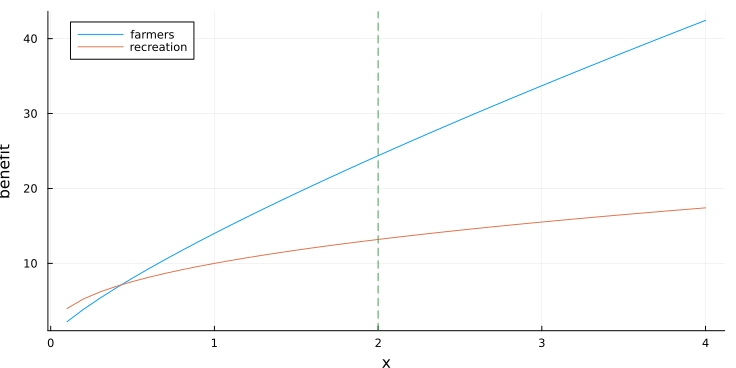

`plot` starts a figure, `plot!` adds to it, `savefig("name.png")` saves it

## You now know enough Julia for this workshop

- Numbers, `≈`, vectors, matrices
- Functions, keywords, two return values, `x -> ...`
- Loops in functions, preallocate and fill, `if`
- Broadcasting with a dot
- `α_1`, and `plot`, `plot!`, `vline!`

Everything from here on is economics and one modeling language

# 2. One reservoir, one season

## The setting

One reservoir. It holds $s = 4$ units of water this season

- In spring, release $x$ units for irrigation. Farmers receive $F(x)$
- Over the summer the reservoir holds $s - x$. Recreational users receive $U(s - x)$
- Then the season ends. **There is no tomorrow** (in the model). We’ll relax this next week

## The model

$$\max_{0 \le x \le 4} \; F(x) + U(4 - x), \qquad F(x) = \alpha_1 x^{\beta_1}, \quad U(z) = \alpha_2 z^{\beta_2}$$

| $\alpha_1 = 14$, $\beta_1 = 0.8$ | farmers |
| --- | --- |
| $\alpha_2 = 10$, $\beta_2 = 0.4$ | recreation |

- Both benefits are increasing and concave, and both marginal benefits blow up at zero, so the answer is interior
- First-order condition: $F'(x) = U'(4 - x)$

*The calibration is based on Miranda and Fackler, Chapter 7.

## Open `s1_inclass.jl`

```julia
α_1 = 14.0;  β_1 = 0.8
α_2 = 10.0;  β_2 = 0.4
s_bar = 4.0
F(x)  = α_1 * x^β_1
U(z)  = α_2 * z^β_2
dF(x) = α_1 * β_1 * x^(β_1 - 1)
dU(z) = α_2 * β_2 * z^(β_2 - 1)
```

The setup block is given. Blanks start after it

## Look before you solve

```julia
W(x) = F(x) + U(s_bar - x)
x_grid = 0.01:0.01:3.99
plot(x_grid, W.(x_grid); xlabel = "x, released for irrigation", ylabel = "F(x) + U(4 - x)", label = false)
```

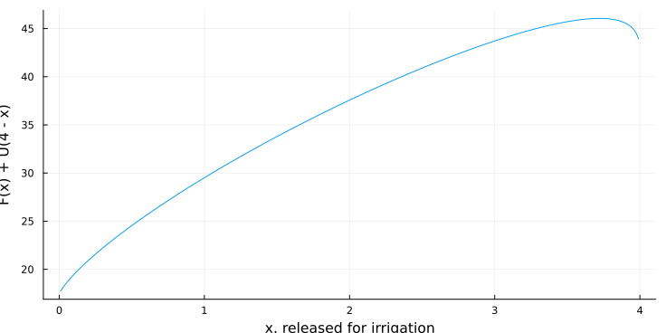

## Way 1: a one-line optimizer

`Optim.optimize(f, a, b)` **minimizes** `f` on `[a, b]`. We want a maximum, so hand it $-W$

```julia
result  = optimize(x -> -W(x), 0.0, s_bar)
x_optim = Optim.minimizer(result)
```

```
3.7214056616224136
```

That is blank 1. One line, and it needs the anonymous function from earlier

## Way 2: a modeling language

**JuMP** lets you write an optimization problem the way you write it on paper: variables, constraints, an objective

A **solver** is the separate program that finds the answer. Today: **Ipopt**, open source, for smooth nonlinear problems

JuMP hands the problem to the solver and hands the answer back. Change one line and the same model goes to a different solver

## Way 2: the model, side by side

$$\begin{aligned}
\max_{x} \;& \alpha_1 x^{\beta_1} + \alpha_2 (4 - x)^{\beta_2} \\
\text{s.t. } & 0 \le x \le 4
\end{aligned}$$

```julia
model = Model(Ipopt.Optimizer)
set_silent(model)
@variable(model, 0 <= x <= s_bar, start = s_bar / 2)
@objective(model, Max, α_1 * x^β_1 + α_2 * (s_bar - x)^β_2)
```

- Line 3 is a **variable with bounds**. Line 4 is the objective, typed as math
- `start` is where Ipopt begins searching. Interior is safest
- Those two lines are blank 2

## Way 2: look at what you wrote

```julia
print(model)
```

```
Max 14 * (x ^ 0.8) + 10 * ((-x + 4) ^ 0.4)
Subject to
 x ≥ 0
 x ≤ 4
```

Then solve, check, and read

```julia
optimize!(model)
@assert is_solved_and_feasible(model)
x_jump = value(x)
```

```
3.721405661580687
```

Never call `value` before checking the solve succeeded. `termination_status(model)` tells you why it stopped:

```julia
termination_status(model)
```

```
LOCALLY_SOLVED::TerminationStatusCode = 4
```

## Verify, do not memorize

Blank 3. At the optimum $F'(x) = U'(4 - x)$. So compute the difference

```julia
residual = dF(x_jump) - dU(s_bar - x_jump)
```

```
8.32366353620273e-9
```

Computationally zero (up to the solver’s tolerance). This is how you should check if you have an actual solution

```julia
isapprox(x_optim, x_jump; atol = 1e-6)
```

```
true
```

Two methods, one solution

## What the answer says

```
x*              = 3.7214
share irrigated = 93.04%
W*              = 46.0562
all irrigation  = 42.4401
all recreation  = 17.411
```

- The planner irrigates 93% of the water
- The optimum beats “irrigate everything” by about 8.5%. Small but honest (this is a stylized model with one season)
- The interesting part is what changes when the season is not the end of the world

## Break

Eight minutes

# 3. What the static model says and what it misses

## Wrap it in a function

```julia
function solve_static(s)
    model = Model(Ipopt.Optimizer)
    set_silent(model)
    @variable(model, 0 <= x <= s, start = s / 2)
    @objective(model, Max, α_1 * x^β_1 + α_2 * (s - x)^β_2)
    optimize!(model)
    @assert is_solved_and_feasible(model)
    x_opt = value(x)
    return x_opt, s - x_opt, F(x_opt) + U(s - x_opt)
end
solve_static(4.0)
```

```
(3.721405661580687, 0.278594338419313, 46.05616209794752)
```

Same code from before, but now `s` is an argument and three numbers are returned: the irrigation, the recreation, and the total benefit

## How does the optimum change with the reservoir level?

Blank 4. Preallocate three vectors, solve at each `s`, store the three results

```julia
function static_paths(s_grid)
    n = length(s_grid)
    x_path = zeros(n); z_path = zeros(n); W_path = zeros(n)
    for i in 1:n
        x_path[i], z_path[i], W_path[i] = solve_static(s_grid[i])
    end
    return x_path, z_path, W_path
end
s_grid = 1.0:0.5:30.0
x_path, z_path, W_path = static_paths(s_grid);
```

## The static planner always drains the reservoir

```julia
share = 100 .* x_path ./ s_grid
plot(s_grid, share; xlabel = "s, water in the reservoir", ylabel = "% released for irrigation", label = false, ylims = (80, 100))
```

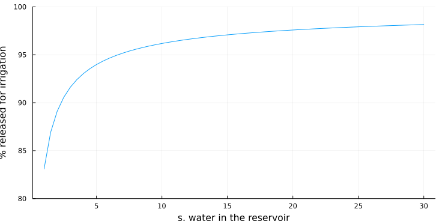

From 83% at one unit of water to 98% at a full reservoir. The more water there is, the more it goes to irrigation

## Why?

Nothing in the objective values water **tomorrow**

$$\text{static:}\qquad F'(x) = U'(s - x)$$

$$\text{dynamic:}\qquad F'(x_t) = U'(s_t - x_t) + \color{#c22}{\delta \, \lambda_{t+1}}$$

$\lambda_{t+1}$ is the value of one more unit of water in the reservoir next year. The static problem sets it to zero

## How big is the missing term?

Next session we compute it. Here is the answer calculated at the level where the reservoir settles in the long run:

$$\lambda = \underbrace{0.975}_{\text{recreation now}} + \underbrace{8.775}_{\delta \, \lambda_{\text{next year}}} = 9.750$$

Ninety percent of what the water is worth is missing from today’s problem! That’s the reason the static planner drains the reservoir.

In the next two weeks, we’ll cover how to add it to the model and solve it

## Take it further

`exercises/s1_homework.jl`, solutions in `solutions/`

1. **Who gets what.** At $s = 4$, walk $x$ across $(0, 4)$ and plot $F(x)$, $U(4 - x)$ and their sum with vertical lines at $0$, $x^*$ and $4$. Read off each party’s gain and loss as you move away from the optimum
2. **Scarcity changes the stakes.** Redo it at $s = 1$ and $s = 30$. The optimum beats all-irrigation by 21% at $s = 1$ and by 2% at $s = 30$. When is the allocation worth arguing about?
3. **Stretch.** The FOC rearranges to $x + c \, x^{1/3} = s$. Write a [bisection search](https://en.wikipedia.org/wiki/Bisection_method) (Ch. 3.1) that solves it and confirm it matches Optim and Ipopt.

## Next session

1. Julia, optimization, and a static reservoir
2. **The Bellman equation on a discrete state**: the stock links the years, the unknown is a function, and on a grid a function is a vector
3. Continuous state: finite and infinite horizon